# COSC-523: Project 04

**Daniel Carter**

[Notebook Link](https://colab.research.google.com/drive/1T5J7qJgDv2cbumwXANT4S3S4Wo61LJUv?usp=sharing)

## Getting Started

Follow the instructions below to copy this notebook and to perform some initial setup.

1. Copy this notebook by selecting `File > Save a copy in Drive`.
2. A new window should open for the copied notebook. Move the new notebook to your course folder in Google Drive by selecting `File > Move` and then selecting the desired folder.
3. Update the name of the notebook by removing "Copy of" and replacing "Username" with your actual username.
4. Update the first cell in the notebook by specifying your course number (423 or 523) and by replacing "**Student Name**" with your actual name.
5. Do not edit the line that says `PLACEHOLDER_FOR_NOTEBOOK_LINK`. This will be used by the [Notebook Renderer](https://colab.research.google.com/drive/1CJTipys46ldZxJFwnt7XbdjQUfkmoXeU?usp=sharing) tool to insert a link to your Colab notebook.
6. Enable link sharing for your notebook.

# Project Description: 3D Object Detection Using Stereo Vision and YOLO

### Summary:

This project uses a stereo image pair and the YOLO object detection model (v5 or v8) to estimate the 3D coordinates of detected objects. Objects are first detected in both the left and right images using YOLO. Matching objects across views are identified based on class label and spatial proximity. Then, depth is estimated via disparity between the x-coordinates of matched detections. Using camera intrinsics (focal length and baseline), the 3D position (X, Y, Z) of each object is computed. Finally, the results are visualized in a 3D scatter plot showing the real-world spatial layout of the detected objects.

### Instructions:

The entire code is given to you with some statements missing and the instructions are provided as comments wherever necessary:

Good luck!

```python
# Installing the correct libraries

!pip install ultralytics
import cv2
import numpy as np
from ultralytics import YOLO
import matplotlib.pyplot as plt
```

```python
# Upload im0 and im1 from Lab 08
left_img = cv2.imread('im0.png')
right_img = cv2.imread('im1.png')
```

```python
# 1. Load any YOLO model of your choosing in a variable named model
model = YOLO('yolov8n.pt')
```

```python
# 2. Load stereo image pair in variables right_img and left_img (im1 is right)
#Done in the first cell. I just loaded the images into memory
```

```python
# 3. Detect objects in both images and store the results in results_right and results_left
results_right = model(right_img)
results_left = model(left_img)
```

```
0: 384x640 27 chairs, 52.6ms
Speed: 7.2ms preprocess, 52.6ms inference, 160.4ms postprocess per image at shape (1, 3, 384, 640)

0: 384x640 25 chairs, 7.8ms
Speed: 3.7ms preprocess, 7.8ms inference, 1.7ms postprocess per image at shape (1, 3, 384, 640)
```

```python
# 4. Extract bounding boxes and classes (first result only) and store them in variables boxes_left, labels_left, boxes_right, labels_right
boxes_left = results_left[0].boxes.xyxy.cpu().numpy()
labels_left = results_left[0].boxes.cls.cpu().numpy()
boxes_right = results_right[0].boxes.xyxy.cpu().numpy()
labels_right = results_right[0].boxes.cls.cpu().numpy()
```

```python
# 5. Set a Spatial proximity threshold for object matching (adjust as needed) by assigning maximum difference in x direction to be 50 and y direction to be 30
# and store them in variables: max_x_diff and max_y_diff
max_x_diff = 50
max_y_diff = 30
```

```
Detected chair at (X: 2.3329262733459473, Y: 1.6365622282028198, Z: -6.700553894042969) meters
Detected chair at (X: 1.3498486280441284, Y: 1.2483958005905151, Z: -6.401581764221191) meters
Detected chair at (X: 1.3357436656951904, Y: 1.2353510856628418, Z: -6.334690093994141) meters
Detected chair at (X: -1.7490763664245605, Y: 0.5427570939064026, Z: -8.764452934265137) meters
Detected chair at (X: 2.7086291313171387, Y: 1.7601126432418823, Z: -6.068999767303467) meters
Detected chair at (X: 0.27154868841171265, Y: 2.7867956161499023, Z: -11.828776359558105) meters
Detected chair at (X: -2.904982566833496, Y: 3.4404714107513428, Z: -18.43429183959961) meters
Detected chair at (X: 0.6881265044212341, Y: 2.3263051509857178, Z: -15.328609466552734) meters
```

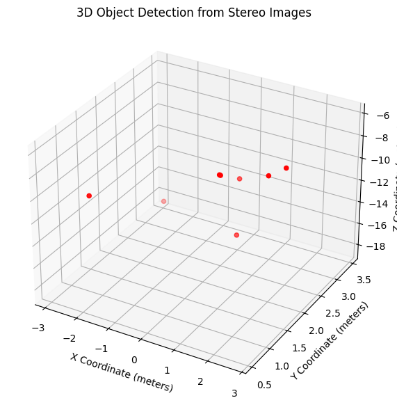

```python
# 5. Match objects between left and right images, here's how:
#    Write a line to initialize an empty list to store matched objects, call this matched_objects
matched_objects = []

# Start a for loop over all bounding boxes from the left image:
for i in range(len(boxes_left)):
# Inside the loop, assign the ith bounding box and label from the left image into box_l and label_l
    box_l = boxes_left[i]
    label_l = labels_left[i]
#### Begin a nested for loop to go over all bounding boxes from the right image:
    for j in range(len(boxes_right)):
#### Inside the nested loop, assign the jth bounding box and label from the right image to box_r and label_r
        box_r = boxes_right[j]
        label_r = labels_right[j]
#### Write an if condition to check whether the labels match:
        if label_l == label_r:
#### Inside this if block, compute the center x and y of the left bounding box:  x_left = (box_l[0] + box_l[2]) / 2
####                                                                             y_left = (box_l[1] + box_l[3]) / 2 #similar for right
            x_left = (box_l[0] + box_l[2]) / 2
            y_left = (box_l[1] + box_l[3]) / 2
######### Write an if condition (this is a nested if) to check if the two centers are within allowed thresholds
            if abs(x_left - box_r[0]) <= max_x_diff and abs(y_left - box_r[1]) <= max_y_diff:
######### Inside this block, calculate the disparity
                disparity = box_r[0] - box_l[2]
################## Add an if block to ignore cases where disparity is 0:
                if disparity != 0:
################## Inside this block, define the stereo camera parameters: focal_length and baseline (take this from Lab08) and calulate depth_z
                  focal_length = 718.856
                  baseline = 0.54
                  depth_z = baseline * focal_length / disparity
################## The rest of the block is given to you
                    # Estimate 3D coordinates (assuming optical center at (cx, cy))
                  cx = left_img.shape[1] / 2
                  cy = left_img.shape[0] / 2

                  x_real = (x_left - cx) * depth_z / focal_length
                  y_real = (y_left - cy) * depth_z / focal_length

                  # Store only numeric data (coordinates and depth)
                  matched_objects.append((float(x_real), float(y_real), float(depth_z)))

                  # Print 3D coordinates for detected object
                  print(f"Detected {model.names[int(label_l)]} at (X: {x_real}, Y: {y_real}, Z: {depth_z}) meters")

# Plot matched objects in 3D if there are any
if len(matched_objects) > 0:
    # Convert matched_objects to numpy array for easy plotting
    objects = np.array(matched_objects)

    # Ensure objects is 2D before plotting
    if objects.ndim == 2:
        # Plot in 3D
        fig = plt.figure(figsize=(10, 7))
        ax = fig.add_subplot(111, projection='3d')

        # Plot only numeric data (coordinates and depth)
        ax.scatter(objects[:, 0], objects[:, 1], objects[:, 2], c='r', marker='o')

        # Labels
        ax.set_xlabel('X Coordinate (meters)')
        ax.set_ylabel('Y Coordinate (meters)')
        ax.set_zlabel('Z Coordinate (meters)')
        ax.set_title('3D Object Detection from Stereo Images')

        plt.show()
else:
    print("No matched objects found.")
```

### Analysis:

Please explain, the output that you see and suggest ways that it can be improved

# Output:

## The output of this graph is showing the detected objects from the YOLO results.

# Improvements:

## This can be improved by doing the following things:

- Improve the accuracy of the disparity maps by using more advanced stereo matching algorithms or refining the process we used above to reduce errors
- Optimize the YOLO model by fine-tuning the chosen model
- Can apply post-processing to reduce noise

# Submission Instructions

1. Perform a Restart and Run All by clicking **Tools > Restart session and run all**.
2. Copy the link to your notebook by clicking **Share > Copy Link**.
3. Paste the copied link into the `notebook_url` field in the [Notebook Renderer](https://colab.research.google.com/drive/1CJTipys46ldZxJFwnt7XbdjQUfkmoXeU?usp=sharing) tool and then execute the cell to render the notebook.
4. The Notebook Renderer will open up a save file dialog. Save the resulting HTML file yo your local machine.
5. Submit the HTML file to Canvas.